# An Analysis of the 2022 Formula One Season

Daniel Henricks

This project was inspired from https://www.kaggle.com/code/ekrembayar/formula-1-70th-anniversary/report#lewis-hamilton-vs-max-verstappen. In addition, some of the code for formatting data was referenced.

# About Formula 1 (F1)

Formula 1 consists of a championship decided by 22 race weekends. Each weekend is composed of practice sessions, qualifying, and a race. Qualifying decides which position the driver starts in, and the race awards points to the fastest 10 drivers, with 1 bonus point for whoever does the fastest lap of the day.

# What is the goal of this project?

For this project, I am analyzing different parts of the 2022 F1 Championship. A few of the results from the 2022 season that I want to analyze are:

- How dominant Red Bull Racing, one of the teams, were.
- The margin of victory by Max Verstappen, the 2022 world champion.
- Whether Verstappen and the Red Bull Racing car are as dominant as Mercedes’ 2018-2020 cars, widely acknowledged as being one of the most dominant racing cars of all time.

### Data formatting and setup for the 2022 year:

This code will read in the data and filter it to only be for races during the year 2022. I also have renamed some fields to make the data easier to work with.

```r
races <- read.csv("archive/races.csv") %>% filter(year == 2022) %>% rename(circuit = name) # each of the 22 F1 races in 2022

driver_standings <- read.csv("archive/driver_standings.csv") %>% # how many points the drivers have
  filter(raceId %in% races$raceId) %>%
  select(-driverStandingsId)

lap_times <- read.csv("archive/lap_times.csv") %>% filter(raceId %in% races$raceId) # how fast each of their laps during the race is

drivers <- read.csv("archive/drivers.csv", encoding = "UTF-8") %>% # these are the names of the drivers
  filter(driverId %in% driver_standings$driverId) %>%
  unite(driver.name, c("forename", "surname"), sep = " ") %>%
  select(driverId, code, number, driver.name) %>%
  rename(driver.number = number)

results <- read.csv("archive/results.csv") %>% filter(raceId %in% races$raceId) # the results of each race

# these are some temporary variables used to select certain columns
gp <- races %>% select(raceId, round, circuit)
dr <- drivers %>% select(driverId, driver.name, code, driver.number)

lap_times %<>%  left_join(gp, by = "raceId") %>%
  left_join(dr, by = "driverId")%>%
  select(-raceId, -driverId)

driver_standings %<>%  left_join(gp, by = "raceId") %>%
  left_join(dr, by = "driverId") %>%
  select(-raceId, -driverId)

results %<>% left_join(gp, by = "raceId") %>%
  left_join(dr, by = "driverId") %>%
  select(-raceId, -driverId)
```

## Intro to Formula 1 and the 2022 year

### About Scoring

Each Formula 1 “team” is composed of two drivers and various other staff. Drivers earn points for themselves in the drivers’ championship and points for their team The better the team does, the more money they get to build next year’s car.

### Final Standings

These are the final standings from 2022’s championship:

```r
ranking_data <- driver_standings %>%
  filter(round == 22) %>% # the final race
  arrange(-points) %>%
  select(driver = driver.name, position, points, wins, code)
datatable(ranking_data, caption = "2022 Formula 1 Driver Championships")
```

|  | driver | position | points | wins | code |
| --- | --- | --- | --- | --- | --- |
| 1 | Max Verstappen | 1 | 454 | 15 | VER |
| 2 | Charles Leclerc | 2 | 308 | 3 | LEC |
| 3 | Sergio Pérez | 3 | 305 | 2 | PER |
| 4 | George Russell | 4 | 275 | 1 | RUS |
| 5 | Carlos Sainz | 5 | 246 | 1 | SAI |
| 6 | Lewis Hamilton | 6 | 240 | 0 | HAM |
| 7 | Lando Norris | 7 | 122 | 0 | NOR |
| 8 | Esteban Ocon | 8 | 92 | 0 | OCO |
| 9 | Fernando Alonso | 9 | 81 | 0 | ALO |
| 10 | Valtteri Bottas | 10 | 49 | 0 | BOT |

[output cut: 12 more lines]

As seen in the table, Verstappen was very dominant in the 2022 season, with Leclerc (Ferrari) and Perez (Red Bull) having a close battle for second. One observation is the point difference between 6th place and 7th place; 7th place starts what is considered as the “midfield,” or drivers who come from teams with less funding. These cars can be up to 1 second per lap slower on average compared to those of the drivers in the top 6.

### Excluding the midfield and below

This code filters the rankings to only select the drivers who scored in the top 6. This helps make some of the following graphs less cluttered.

```r
top_6 <- ranking_data[1:6,]
filtered_top <- driver_standings %>% filter(driver.name %in% top_6$driver)
```

### The Championship Per Race

This is a plot of the standings per race.

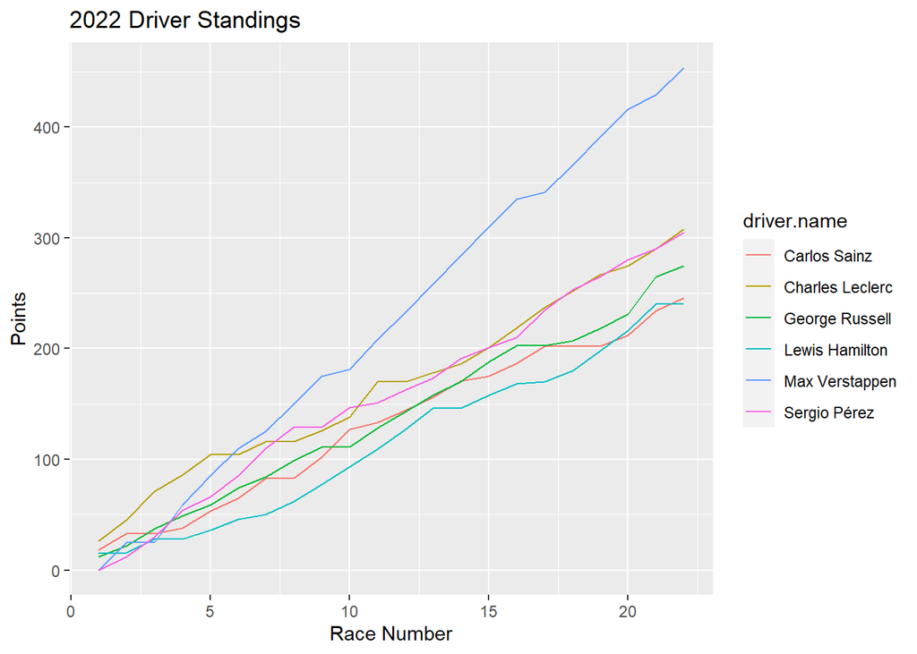

```r
ggplot(filtered_top, aes(round, points, color = driver.name)) + geom_line() + labs(x = "Race Number", y = "Points", title = "2022 Driver Standings")
```

### Example of lap times for a race

Here’s an example of how lap times can be used to show the pace of the fastest drivers throughout the race: Note that I filter out most laps where drivers have to slow down (pit stops, accidents, etc.) to show a more even graph. It should also be noted that Verstappen and Perez (Red Bull’s drivers) both had engine failures in this race.

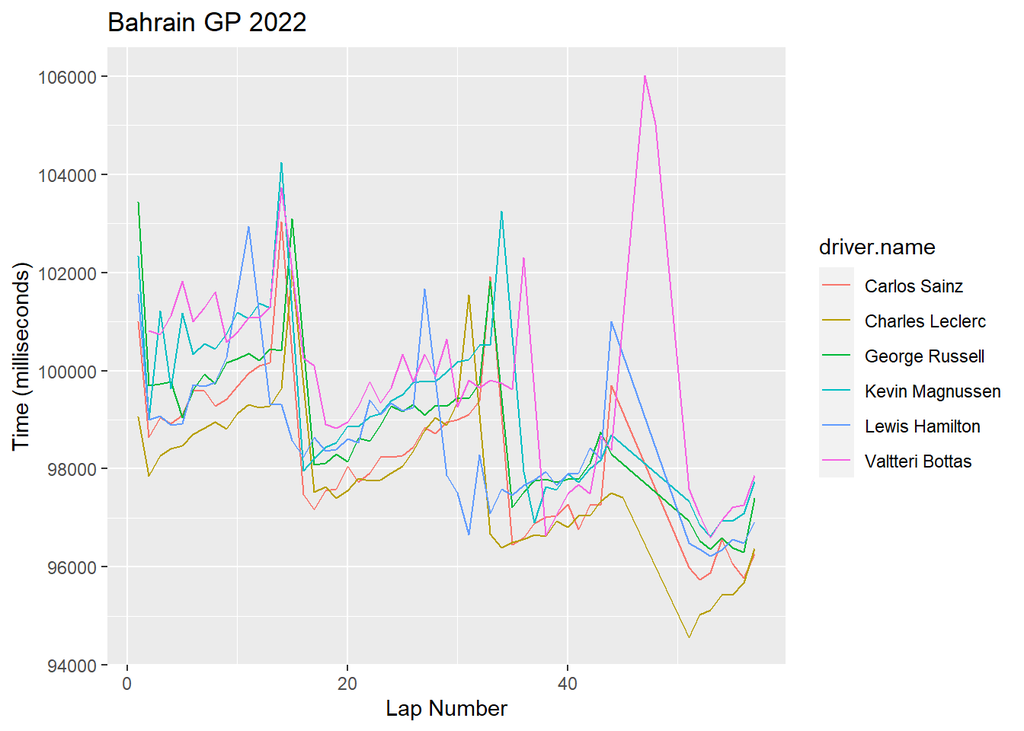

```r
top_6_race_1 <- driver_standings %>%
  filter(round == 1)%>%
  arrange(-points) %>%
  select(driver = driver.name, position, points, wins, code) %>%
  slice(1:6)

race_1 <- lap_times %>%
  filter(round == 1) %>%
  filter(!milliseconds %in% boxplot.stats(milliseconds)$out)%>%
  filter(driver.name %in% top_6_race_1$driver)
ggplot() + geom_line(race_1, mapping=aes(lap, milliseconds, color = driver.name)) + labs(x = "Lap Number", y = "Time (milliseconds)", title = "Bahrain GP 2022")
```

## 1. Red Bull Racing’s Pace Advantage in 2022

To show the dominance that Red Bull had over Mercedes in 2022, see the filtered data below that includes the top 20 fastest laps between the two teams per race. This graph shows the number of those 20 that were achieved in a Red Bull Car, with a line at the expected value of y=10.

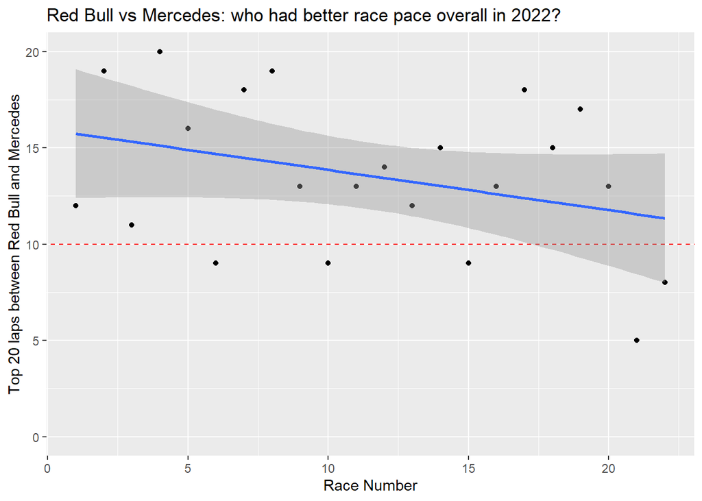

```r
red_bull <- c("VER", "PER")
mercedes <- c("HAM", "RUS")

fastest_lap_times <- lap_times %>%
  arrange(milliseconds) %>%
  filter(code %in% red_bull | code %in% mercedes) %>%
  group_by(round) %>%
  slice(1:20)

lap_times_sum <-fastest_lap_times%>%
  summarise(sum_wins = sum(code %in% red_bull))

ggplot(lap_times_sum, aes(x = round, y = sum_wins)) + geom_point() + geom_abline(intercept=10, slope=0, color = "red",linetype="dashed") + geom_smooth(method="lm") + ggtitle("Red Bull vs Mercedes: who had better race pace overall in 2022?") + xlab("Race Number") + ylab("Top 20 laps between Red Bull and Mercedes") + ylim(0, 20)
```

```r
summary(lm(lap_times_sum$sum_wins ~ lap_times_sum$round))
```

```
##
## Call:
## lm(formula = lap_times_sum$sum_wins ~ lap_times_sum$round)
##
## Residuals:
##     Min      1Q  Median      3Q     Max
## -6.5607 -3.6423  0.4768  3.3055  5.6036
##
## Coefficients:
##                     Estimate Std. Error t value Pr(>|t|)
## (Intercept)          15.9481     1.7174   9.286 1.08e-08 ***
## lap_times_sum$round  -0.2089     0.1308  -1.598    0.126
## ---
## Signif. codes:  0 '***' 0.001 '**' 0.01 '*' 0.05 '.' 0.1 ' ' 1
##
## Residual standard error: 3.891 on 20 degrees of freedom
## Multiple R-squared:  0.1132, Adjusted R-squared:  0.06885
## F-statistic: 2.553 on 1 and 20 DF,  p-value: 0.1258
```

Now to see the mean number of times in the top 20:

```r
num_races <- 22
sum(lap_times_sum$sum_wins)/num_races # Red Bull vs Mercedes top 20 laps
```

```
## [1] 13.54545
```

Now let’s see Red Bull versus every other team (including top 50 laps). The dashed red line is the expected value given that every team has similar cars:

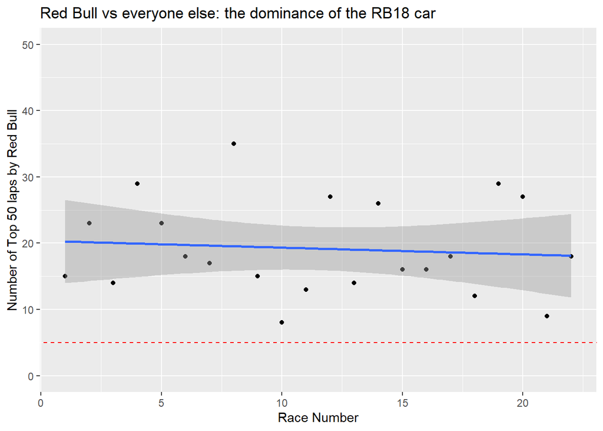

```r
sorted_lap_times <- lap_times %>%
  arrange(milliseconds) %>%
  group_by(round) %>%
  slice(1:50)

red_bull_times <- sorted_lap_times %>% summarise(sum_wins = sum(code %in% red_bull))

ggplot(red_bull_times, aes(x = round, y = sum_wins)) + geom_point() + geom_abline(intercept=5, slope=0, color = "red",linetype="dashed") + geom_smooth(method="lm") + ggtitle("Red Bull vs everyone else: the dominance of the RB18 car") + xlab("Race Number") + ylab("Number of Top 50 laps by Red Bull") + ylim(0, 50)
```

```r
summary(lm(red_bull_times$sum_wins ~ red_bull_times$round))
```

```
##
## Call:
## lm(formula = red_bull_times$sum_wins ~ red_bull_times$round)
##
## Residuals:
##     Min      1Q  Median      3Q     Max
## -11.334  -5.194  -2.190   6.094  15.463
##
## Coefficients:
##                      Estimate Std. Error t value Pr(>|t|)
## (Intercept)           20.3506     3.2255   6.309  3.7e-06 ***
## red_bull_times$round  -0.1016     0.2456  -0.414    0.683
## ---
## Signif. codes:  0 '***' 0.001 '**' 0.01 '*' 0.05 '.' 0.1 ' ' 1
##
## Residual standard error: 7.308 on 20 degrees of freedom
## Multiple R-squared:  0.008491,   Adjusted R-squared:  -0.04108
## F-statistic: 0.1713 on 1 and 20 DF,  p-value: 0.6834
```

Now to find the mean number of laps in the top 50 fastest:

```r
sum(red_bull_times$sum_wins)/num_races
```

```
## [1] 19.18182
```

## Results regarding Red Bull Racing’s dominance

- With about 40% of the fastest laps belonging to Red Bull in 2022, it is clear that their car had a significant pace advantage.
- Red Bull outperformed Mercedes, their usual rival in the championship, by a significant margin with respect to lap pace.
- With their drivers placing 1st and 3rd and winning a combined 17 out of 22 races, their consistency is clear.
- Both of the regression lines were slightly downward sloping, as seen in the coefficients generated by both summaries. An explanation for this is that other teams began to develop their cars during the middle and end of the season in an attempt to catch up to Red Bull.

## 2. Analyzing Verstappen’s dominance in the driver’s championship

To analyze Verstappen’s dominance, I will first show his pace difference between his teammate (Perez) and then expand it to the rest of the field.

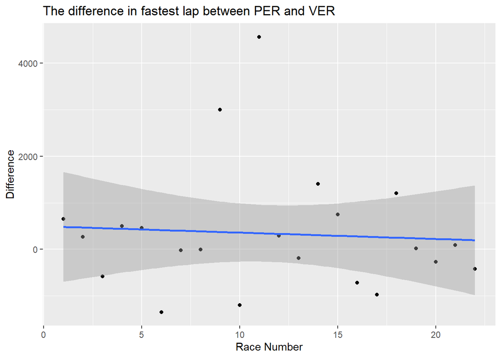

```r
VER_fastest_ms <- lap_times %>%
  filter(code == "VER") %>%
  group_by(round) %>%
  slice(which.min(milliseconds)) # select the min of a group

PER_fastest_ms <- lap_times %>%
  filter(code == "PER") %>%
  group_by(round) %>%
  slice(which.min(milliseconds))

VER_fastest_ms$difference <- PER_fastest_ms$milliseconds - VER_fastest_ms$milliseconds

ggplot(VER_fastest_ms, aes(x = round, y = difference)) + geom_point() + geom_smooth(method="lm") + ggtitle("The difference in fastest lap between PER and VER") + xlab("Race Number") + ylab("Difference")
```

```r
summary(lm(VER_fastest_ms$difference ~ VER_fastest_ms$round))
```

```
##
## Call:
## lm(formula = VER_fastest_ms$difference ~ VER_fastest_ms$round)
##
## Residuals:
##     Min      1Q  Median      3Q     Max
## -1763.7  -589.9  -208.4   138.9  4220.4
##
## Coefficients:
##                      Estimate Std. Error t value Pr(>|t|)
## (Intercept)            497.39     605.05   0.822    0.421
## VER_fastest_ms$round   -13.62      46.07  -0.296    0.771
##
## Residual standard error: 1371 on 20 degrees of freedom
## Multiple R-squared:  0.004351,   Adjusted R-squared:  -0.04543
## F-statistic: 0.0874 on 1 and 20 DF,  p-value: 0.7706
```

As seen by the coefficients in the summary, the regression line featured a positive intercept of 497.39 and a negative slope. There naturally exists lots of variance in this data because of crashes/very small sample size (605.05 std. error on the intercept). However, the results from the 2022 season back up this graph (Verstappen won 15 out of 22 races).

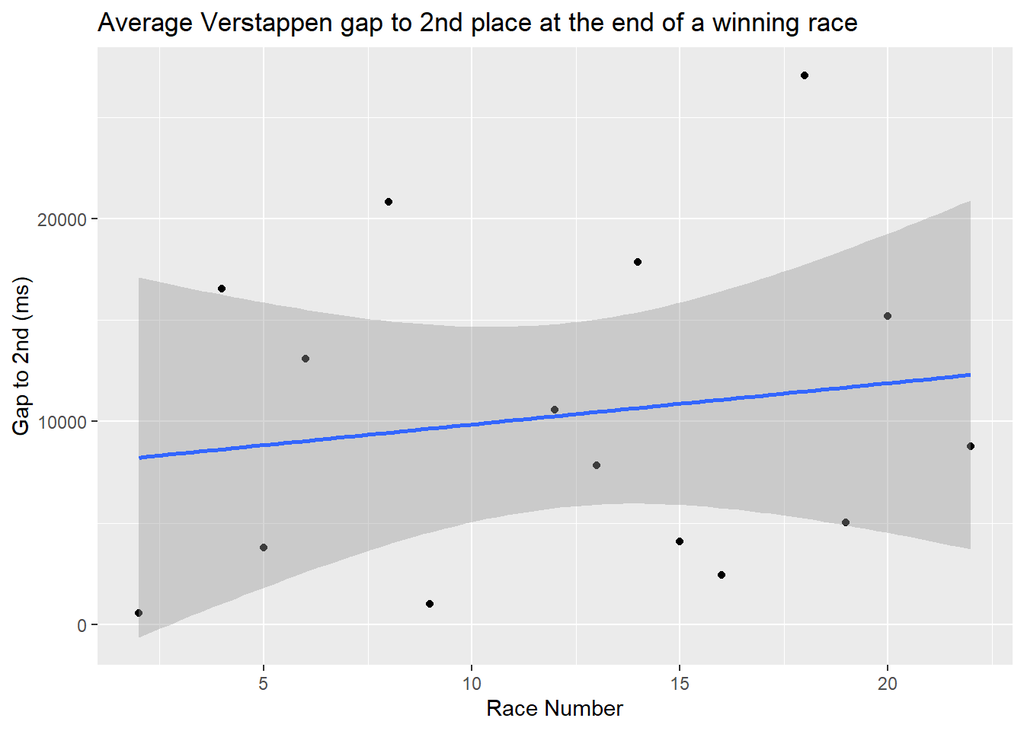

```r
VER_wins <- results %>% filter(code == "VER" & position == 1)
fastest_other <- results %>% filter(round %in% VER_wins$round & position == 2)
VER_wins$gap <- as.numeric(fastest_other$milliseconds) - as.numeric(VER_wins$milliseconds)

ggplot(VER_wins, aes(x = round, y = gap)) + geom_point() + geom_smooth(method="lm") + ggtitle("Average Verstappen gap to 2nd place at the end of a winning race") + xlab("Race Number") + ylab("Gap to 2nd (ms)")
```

```r
summary(lm(VER_wins$gap ~ VER_wins$round))
```

```
##
## Call:
## lm(formula = VER_wins$gap ~ VER_wins$round)
##
## Residuals:
##    Min     1Q Median     3Q    Max
##  -8661  -6735  -2634   5599  15580
##
## Coefficients:
##                Estimate Std. Error t value Pr(>|t|)
## (Intercept)      7821.7     4707.5   1.662    0.121
## VER_wins$round    203.6      345.5   0.589    0.566
##
## Residual standard error: 8120 on 13 degrees of freedom
## Multiple R-squared:  0.02601,    Adjusted R-squared:  -0.04891
## F-statistic: 0.3471 on 1 and 13 DF,  p-value: 0.5658
```

The regression line yields a intercept of 7821.7, or about 7 seconds. The line is slightly positively sloped but not enough to draw a conclusion from (203.6).

Filtering out the races that Perez placed 2nd (similar car):

```r
PER_p2 <- results %>% filter(code == "PER" & position == 2)
fastest_non_perez <- results %>%
  filter(round %in% VER_wins$round) %>%
  filter((position == 2 & !(round %in% PER_p2$round)) | (position == 3 & round %in% PER_p2$round))
```

Explaining the logic behind this code: Consider all rounds in which Verstappen won (15 rounds). In these rounds, I want to have the difference between Verstappen and the fastest non-Red Bull car. If Perez (the other Red Bull) did not take second, include the driver in 2nd place. Otherwise, include the 3rd place time since Perez must have taken 2nd.

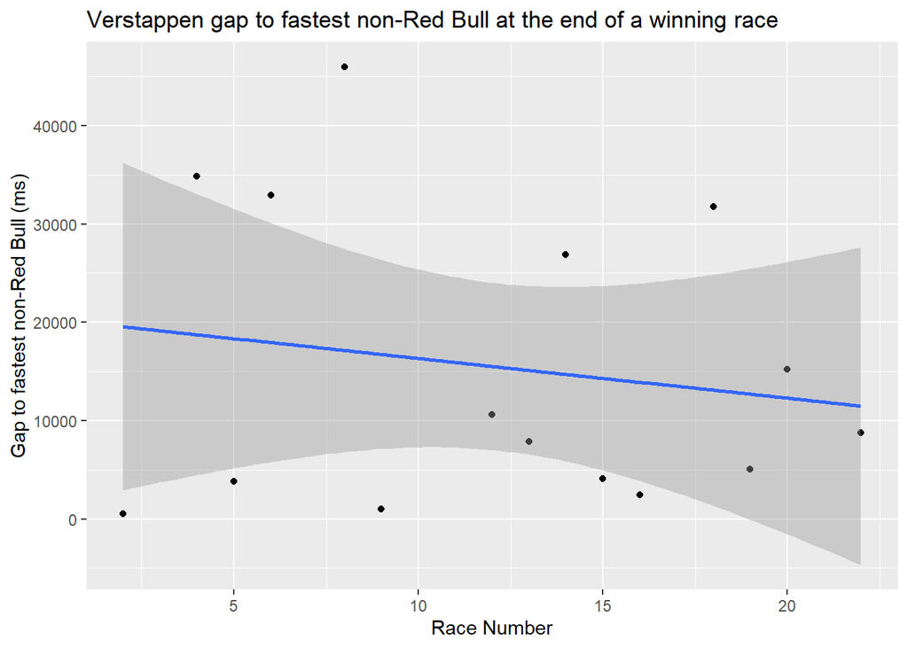

```r
VER_wins$gap <- as.numeric(fastest_non_perez$milliseconds) - as.numeric(VER_wins$milliseconds)
ggplot(VER_wins, aes(x = round, y = gap)) + geom_point() + geom_smooth(method="lm") + ggtitle("Verstappen gap to fastest non-Red Bull at the end of a winning race") + xlab("Race Number") + ylab("Gap to fastest non-Red Bull (ms)")
```

```r
summary(lm(VER_wins$gap ~ VER_wins$round))
```

```
##
## Call:
## lm(formula = VER_wins$gap ~ VER_wins$round)
##
## Residuals:
##    Min     1Q Median     3Q    Max
## -19012 -10853  -4937  13575  28856
##
## Coefficients:
##                Estimate Std. Error t value Pr(>|t|)
## (Intercept)     20367.9     8839.0   2.304   0.0383 *
## VER_wins$round   -403.6      648.7  -0.622   0.5445
## ---
## Signif. codes:  0 '***' 0.001 '**' 0.01 '*' 0.05 '.' 0.1 ' ' 1
##
## Residual standard error: 15250 on 13 degrees of freedom
## Multiple R-squared:  0.02892,    Adjusted R-squared:  -0.04578
## F-statistic: 0.3872 on 1 and 13 DF,  p-value: 0.5445
```

This filtering process shows how much faster both Verstappen and the Red Bull team were. The intercept is now 20367.9 (20 seconds), making a 13 second difference in removing these times. The slope (inferring that the variance) of the data is much larger and negative sloping as well, similar to what was seen in the previous graphs.

### Results regarding Verstappen’s dominance

- Verstappen clearly was the fastest driver in 2022, with the difference in time between second and first when he won being very large.
- Perez was a great supporting driver for Verstappen, allowing him to gain time on other drivers in the race.
- The trend that other cars were developing faster than Red Bull continues to show in this data with another negatively-sloping regression line.
- It remains to be seen whether an average of 20 seconds between other teams was more than what Mercedes had in their most dominant years.

## 3. 2020’s Mercedes year and the W11 compared to 2022 and the Red Bull

### Info about 2020’s season:

Here’s a datatable containing the results from 2020:

```r
rankings <- driver_standings_2020 %>%
  filter(round == 17) %>% # the final race
  arrange(-points) %>%
  select(driver = driver.name, points, wins, code)
datatable(rankings, caption = "2020 Formula 1 Driver Championships")
```

|  | driver | points | wins | code |
| --- | --- | --- | --- | --- |
| 1 | Lewis Hamilton | 347 | 11 | HAM |
| 2 | Valtteri Bottas | 223 | 2 | BOT |
| 3 | Max Verstappen | 214 | 2 | VER |
| 4 | Sergio Pérez | 125 | 1 | PER |
| 5 | Daniel Ricciardo | 119 | 0 | RIC |
| 6 | Carlos Sainz | 105 | 0 | SAI |
| 7 | Alexander Albon | 105 | 0 | ALB |
| 8 | Charles Leclerc | 98 | 0 | LEC |
| 9 | Lando Norris | 97 | 0 | NOR |
| 10 | Pierre Gasly | 75 | 1 | GAS |

[output cut: 13 more lines]

Lewis Hamilton and Valtteri Bottas (1st and 2nd) were teammates during the 2020 season for Mercedes, with Verstappen and Albon (7th) driving for Red Bull in 2020. Because of COVID, the season was shorter than normal (17 races).

I’m more interested about the team (the car) than the dynamic between the drivers. To see if this year’s Mercedes car was as dominant as people think it is, let me run a few tests:

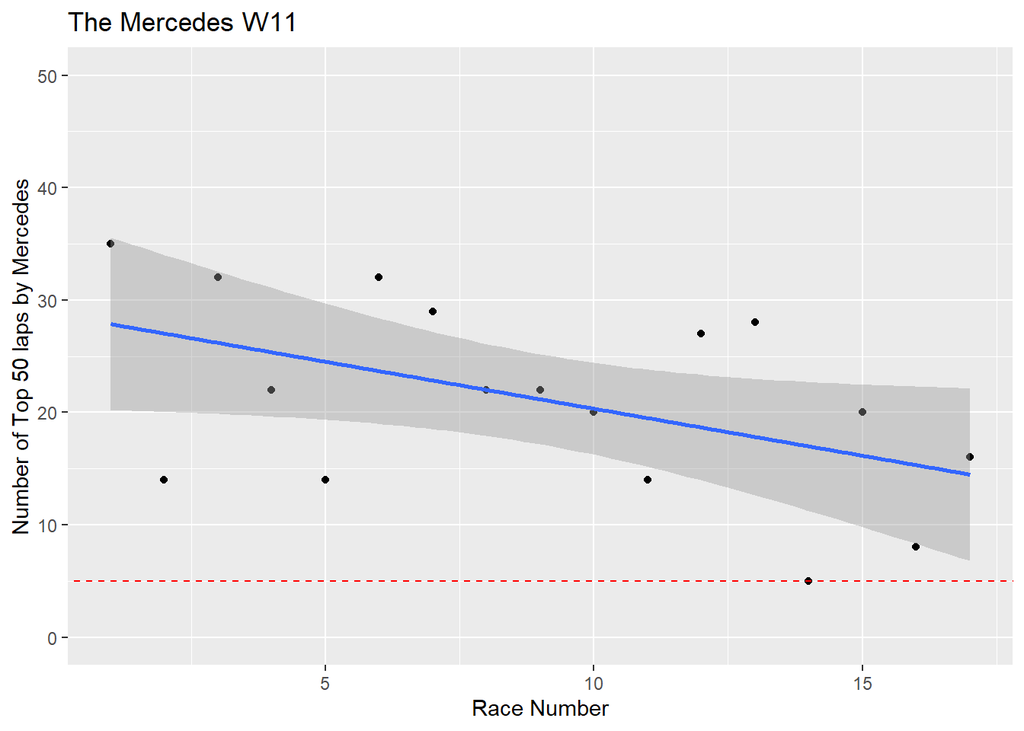

```r
mercedes <- c("HAM", "BOT")

sorted_lap_times <- lap_times_2020 %>%
  arrange(milliseconds) %>%
  group_by(round) %>%
  slice(1:50)

merc_times <- sorted_lap_times %>% summarise(sum_wins = sum(code %in% mercedes))

ggplot(merc_times, aes(x = round, y = sum_wins)) + geom_point() + geom_abline(intercept=5, slope=0, color = "red",linetype="dashed") + geom_smooth(method="lm") + ggtitle("The Mercedes W11") + xlab("Race Number") + ylab("Number of Top 50 laps by Mercedes") + ylim(0, 50)
```

```r
summary(lm(merc_times$sum_wins ~ merc_times$round))
```

```
##
## Call:
## lm(formula = merc_times$sum_wins ~ merc_times$round)
##
## Residuals:
##      Min       1Q   Median       3Q      Max
## -13.0441  -5.5000   0.8235   6.1471  10.1765
##
## Coefficients:
##                  Estimate Std. Error t value Pr(>|t|)
## (Intercept)       28.7206     3.9334   7.302  2.6e-06 ***
## merc_times$round  -0.8382     0.3839  -2.184   0.0453 *
## ---
## Signif. codes:  0 '***' 0.001 '**' 0.01 '*' 0.05 '.' 0.1 ' ' 1
##
## Residual standard error: 7.754 on 15 degrees of freedom
## Multiple R-squared:  0.2412, Adjusted R-squared:  0.1906
## F-statistic: 4.768 on 1 and 15 DF,  p-value: 0.04528
```

Wow! Mercedes has a much more dominant graph in terms of top 50 laps. Note that race 14 (Turkey, the one on the E(x) = 5 line) was super rainy. Rain is known as the “great equalizer” in Formula 1: it makes it much easier for other cars to go fast. Other than this outlier, the slope of the regression line is still very interesting and follows the same trend as in previous parts: other teams catch up to the fastest team as the season goes on.

The equation for the regression line is y = -0.8382x + 28.7206.

### The difference in time between Lewis Hamilton and 2nd (including Mercedes) at the end of the race:

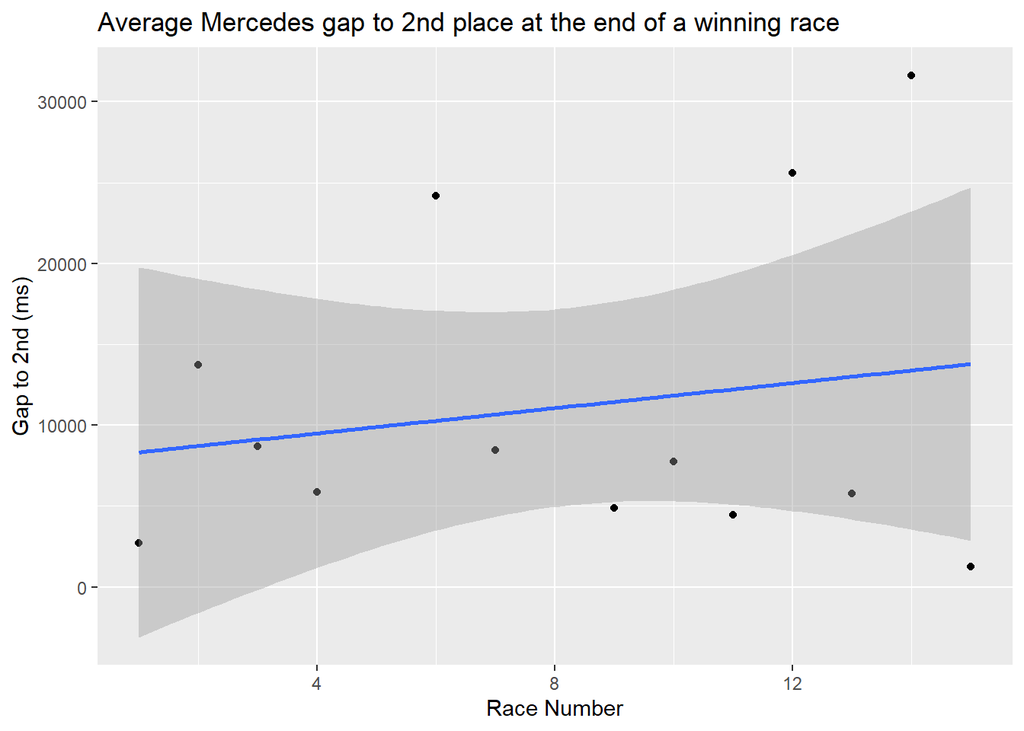

```r
HAM_wins <- results_2020 %>% filter((code == "HAM" & position == 1)| (code == "BOT" & position == 1))
fastest_other <- results_2020 %>% filter(round %in% HAM_wins$round & position == 2)
HAM_wins$gap <- as.numeric(fastest_other$milliseconds) - as.numeric(HAM_wins$milliseconds)

ggplot(HAM_wins, aes(x = round, y = gap)) + geom_point() + geom_smooth(method="lm") + ggtitle("Average Mercedes gap to 2nd place at the end of a winning race") + xlab("Race Number") + ylab("Gap to 2nd (ms)")
```

```r
summary(lm(HAM_wins$gap ~ HAM_wins$round))
```

```
##
## Call:
## lm(formula = HAM_wins$gap ~ HAM_wins$round)
##
## Residuals:
##    Min     1Q Median     3Q    Max
## -12530  -6569  -3647   4995  18238
##
## Coefficients:
##                Estimate Std. Error t value Pr(>|t|)
## (Intercept)      7945.9     5719.5   1.389    0.192
## HAM_wins$round    389.2      607.8   0.640    0.535
##
## Residual standard error: 9994 on 11 degrees of freedom
## Multiple R-squared:  0.03594,    Adjusted R-squared:  -0.05171
## F-statistic:  0.41 on 1 and 11 DF,  p-value: 0.5351
```